# Use Keras to recognize hand-written digits with `ibm-watsonx-ai`

This notebook uses the Keras machine learning framework with the `watsonx.ai` service. It contains steps and code to work with ibm-watsonx-ai library available in PyPI repository. It also introduces commands for getting model and training data, persisting model, deploying model and scoring it.

Some familiarity with Python is helpful. This notebook uses Python 3.12.

## Learning goals

The learning goals of this notebook are:

- Download an externally trained Keras model with dataset.
- Persist an external model in `watsonx.ai` repository.
- Deploy model for online scoring using client library.
- Score sample records using client library.

## Contents

This notebook contains the following parts:

1. Setup
2. Download externally created Keras model and data
3. Persist externally created Keras model
4. Online Deployment
5. Clean up
6. Summary and next steps

## 1. Set up the environment

Before you use the sample code in this notebook, you must perform the following setup tasks:

- Contact with your Cloud Pak for Data administrator and ask them for your account credentials

### Install dependencies

**Note:** `ibm-watsonx-ai` documentation can be found [here](https://ibm.github.io/watsonx-ai-python-sdk/index.html).

```python
%pip install -U wget | tail -n 1
%pip install -U matplotlib | tail -n 1
%pip install -U ibm-watsonx-ai | tail -n 1
```

#### Define credentials

Authenticate the watsonx.ai Runtime service on IBM Cloud Pak for Data. You need to provide the **admin's** `username` and the platform `url`.

```python
username = "PASTE YOUR USERNAME HERE"
url = "PASTE THE PLATFORM URL HERE"
```

Use the **admin's** `api_key` to authenticate watsonx.ai Runtime services:

```python
import getpass
from ibm_watsonx_ai import Credentials

credentials = Credentials(
    username=username,
    api_key=getpass.getpass("Enter your watsonx.ai API key and hit enter: "),
    url=url,
    instance_id="openshift",
    version="5.2",
)
```

Alternatively you can use the **admin's** `password`:

```python
import getpass
from ibm_watsonx_ai import Credentials

if "credentials" not in locals() or not credentials.api_key:
    credentials = Credentials(
        username=username,
        password=getpass.getpass("Enter your watsonx.ai password and hit enter: "),
        url=url,
        instance_id="openshift",
        version="5.2",
    )
```

#### Create `APIClient` instance

```python
from ibm_watsonx_ai import APIClient

client = APIClient(credentials)
```

### Working with spaces

First of all, you need to create a space that will be used for your work. If you do not have space already created, you can use `{PLATFORM_URL}/ml-runtime/spaces?context=icp4data` to create one.

- Click New Deployment Space
- Create an empty space
- Go to space `Settings` tab
- Copy `space_id` and paste it below

**Tip**: You can also use SDK to prepare the space for your work. More information can be found [here](https://github.com/IBM/watsonx-ai-samples/blob/master/cpd5.2/notebooks/python_sdk/instance-management/Space%20management.ipynb).

**Action**: Assign space ID below

```python
space_id = "PASTE YOUR SPACE ID HERE"
```

You can use `list` method to print all existing spaces.

```python
client.spaces.list(limit=10)
```

To be able to interact with all resources available in watsonx.ai, you need to set **space** which you will be using.

```python
client.set.default_space(space_id)
```

```
'SUCCESS'
```

## 2. Download externally created Keras model and data

In this section, you will download externally created Keras models and data used for training it.

```python
import os
import wget

model_path = "mnist-keras-model.h5.zip"
if not os.path.isfile(model_path):
    wget.download(
        f"https://github.com/IBM/watsonx-ai-samples/raw/master/cpd5.2/models/keras/{model_path}"
    )
```

```python
data_dir = "MNIST_DATA"
if not os.path.isdir(data_dir):
    os.mkdir(data_dir)

filename = os.path.join(data_dir, "mnist.npz")
if not os.path.isfile(filename):
    wget.download("https://s3.amazonaws.com/img-datasets/mnist.npz", out=data_dir)
```

```python
import numpy as np

dataset = np.load(filename)
x_test = dataset["x_test"]
```

## 3. Persist externally created Keras model

In this section, you will learn how to store your model in `watsonx.ai` repository by using the `watsonx.ai` Client.

### 3.1: Publish model

#### Publish model in `watsonx.ai` repository.

Define model name, type and software specification needed to deploy model later.

```python
software_spec_uid = client.software_specifications.get_id_by_name("runtime-25.1-py3.12")
```

```python
metadata = {
    client.repository.ModelMetaNames.NAME: "External Keras model",
    client.repository.ModelMetaNames.TYPE: "tensorflow_2.18",
    client.repository.ModelMetaNames.SOFTWARE_SPEC_UID: software_spec_uid,
}

published_model = client.repository.store_model(model=model_path, meta_props=metadata)
```

### 3.2: Get model details

```python
import json

published_model_uid = client.repository.get_model_id(published_model)
model_details = client.repository.get_details(published_model_uid)
print(json.dumps(model_details, indent=2))
```

```
{
  "metadata": {
    "name": "External Keras model",
    "space_id": "8a13841b-df99-4b4d-bf2a-161ad2e33980",
    "resource_key": "25a59569-0d92-486a-838c-6031853c6990",
    "id": "aad6ada7-be37-4e29-aba3-19162f750bb1",
    "created_at": "2025-06-20T12:29:37Z",
    "rov": {
      "member_roles": {
        "1000331001": {
          "user_iam_id": "1000331001",
          "roles": [
            "OWNER"
          ]
        }
      }
    },
    "owner": "1000331001"
  },
  "entity": {
    "software_spec": {
      "id": "f47ae1c3-198e-5718-b59d-2ea471561e9e"
    },
    "type": "tensorflow_2.18"
  }
}
```

### 3.3 Get all models

```python
models_details = client.repository.list_models()
```

## 4. Online deployment

In this section you will learn how to create online scoring and to score a new data record by using the `watsonx.ai` Client.

### 4.1: Create model deployment

#### Create online deployment for published model

```python
metadata = {
    client.deployments.ConfigurationMetaNames.NAME: "Deployment of external Keras model",
    client.deployments.ConfigurationMetaNames.ONLINE: {},
}

created_deployment = client.deployments.create(published_model_uid, meta_props=metadata)
```

```
######################################################################################

Synchronous deployment creation for id: 'aad6ada7-be37-4e29-aba3-19162f750bb1' started

######################################################################################


initializing
Note: online_url is deprecated and will be removed in a future release. Use serving_urls instead.
........
ready


-----------------------------------------------------------------------------------------------
Successfully finished deployment creation, deployment_id='25899b93-8b6e-48cb-83a2-e8cc7c6b31f9'
-----------------------------------------------------------------------------------------------
```

**Note**: Here we use deployment URL saved in `published_model` object. In next section, we show how to retrive deployment url from `watsonx.ai` instance.

```python
deployment_uid = client.deployments.get_id(created_deployment)
```

Now you can print an online scoring endpoint.

```python
scoring_endpoint = client.deployments.get_scoring_href(created_deployment)
print(scoring_endpoint)
```

[output not shown]

You can also list existing deployments.

```python
client.deployments.list()
```

|  | ID | NAME | STATE | CREATED | ARTIFACT_TYPE | SPEC_STATE | SPEC_REPLACEMENT |
| --- | --- | --- | --- | --- | --- | --- | --- |
| 0 | 25899b93-8b6e-48cb-83a2-e8cc7c6b31f9 | Deployment of external Keras model | ready | 2025-06-20T12:29:59.404Z | model | supported |  |

### 4.2: Get deployment details

```python
client.deployments.get_details(deployment_uid)
```

### 4.3: Score

You can use below method to do test scoring request against deployed model.

Let's first visualize two samples from dataset, we'll use for scoring.

```python
%matplotlib inline
import matplotlib.pyplot as plt
```

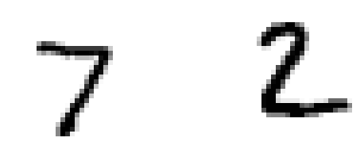

```python
for i, image in enumerate([x_test[0], x_test[1]]):
    plt.subplot(2, 2, i + 1)
    plt.axis("off")
    plt.imshow(image, cmap=plt.cm.gray_r, interpolation="nearest")
```

Prepare scoring payload with records to score.

```python
score_0 = x_test[0].reshape(28, 28, 1)
score_1 = x_test[1].reshape(28, 28, 1)
```

```python
scoring_payload = {"input_data": [{"values": [score_0, score_1]}]}
```

Use `client.deployments.score()` method to run scoring.

```python
predictions = client.deployments.score(deployment_uid, scoring_payload)
```

```python
print(json.dumps(predictions, indent=2))
```

```
{
  "predictions": [
    {
      "fields": [
        "prediction"
      ],
      "id": "y_hat",
      "values": [
        [
          2.1161436052352656e-06,
          9.53357170985214e-10,
          4.728389346730921e-10,
          3.943275572737548e-08,
          0.00011951127089560032,
          1.438263979025578e-07,
          2.1252301252161487e-08,
          0.9995545744895935,
          8.875564958543691e-07,
          0.0003227672423236072
        ],
        [
          0.021077046170830727,
          0.1209486722946167,
          0.8552001714706421,
          0.0012876029359176755,
          4.0436454582959414e-05,
          0.0004892426659353077,
          0.00048998644342646,
          9.553693234920502e-05,
          0.00018569448729977012,
          0.00018568598898127675
        ]
      ]
    }
  ]
}
```

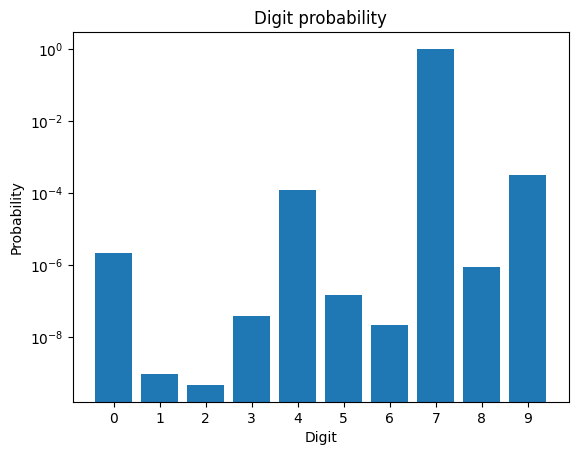

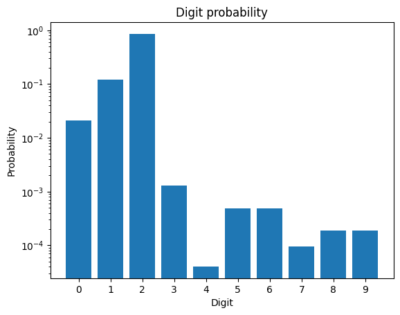

```python
for i, prediction in enumerate(predictions["predictions"][0]["values"]):
    plt.bar(range(10), prediction)
    plt.title("Digit probability")
    plt.xlabel("Digit")
    plt.ylabel("Probability")
    plt.xticks(range(10))
    plt.yscale("log")
    plt.show()
```

As you can see, predicted values are the same one as displayed above from test dataset.

## 5. Clean up

If you want to clean up all created assets:

- experiments
- trainings
- pipelines
- model definitions
- models
- functions
- deployments

please follow up this sample [notebook](https://github.com/IBM/watsonx-ai-samples/blob/master/cpd5.2/notebooks/python_sdk/instance-management/Machine%20Learning%20artifacts%20management.ipynb).

## 6. Summary and next steps

You successfully completed this notebook! You learned how to use Keras machine learning library as well as `watsonx.ai` for model creation and deployment.

Check out our *[Online Documentation](https://ibm.github.io/watsonx-ai-python-sdk/samples.html)* for more samples, tutorials, documentation, how-tos, and blog posts.

### Authors

**Daniel Ryszka**, Software Engineer

Copyright © 2020-2025 IBM. This notebook and its source code are released under the terms of the MIT License.